# Risk Factor Analysis

## Outcome Variable

**Outcome Variable:** swasted

## Predictor Variables

**Intervention Variable:** enstunt

**Adjustment Set:**

unadjusted

## Stratifying Variables

The analysis was stratified on these variable(s):

- agecat
- studyid
- country

## Data Summary

| agecat | studyid | country | enstunt | swasted | n_cell | n |
| --- | --- | --- | --- | --- | --- | --- |
| Birth | ki0047075b-MAL-ED | BANGLADESH | 0 | 0 | 179 | 215 |
| Birth | ki0047075b-MAL-ED | BANGLADESH | 0 | 1 | 8 | 215 |
| Birth | ki0047075b-MAL-ED | BANGLADESH | 1 | 0 | 28 | 215 |
| Birth | ki0047075b-MAL-ED | BANGLADESH | 1 | 1 | 0 | 215 |
| Birth | ki0047075b-MAL-ED | BRAZIL | 0 | 0 | 56 | 62 |
| Birth | ki0047075b-MAL-ED | BRAZIL | 0 | 1 | 0 | 62 |
| Birth | ki0047075b-MAL-ED | BRAZIL | 1 | 0 | 6 | 62 |
| Birth | ki0047075b-MAL-ED | BRAZIL | 1 | 1 | 0 | 62 |
| Birth | ki0047075b-MAL-ED | INDIA | 0 | 0 | 37 | 45 |
| Birth | ki0047075b-MAL-ED | INDIA | 0 | 1 | 0 | 45 |
| Birth | ki0047075b-MAL-ED | INDIA | 1 | 0 | 8 | 45 |
| Birth | ki0047075b-MAL-ED | INDIA | 1 | 1 | 0 | 45 |
| Birth | ki0047075b-MAL-ED | NEPAL | 0 | 0 | 24 | 26 |
| Birth | ki0047075b-MAL-ED | NEPAL | 0 | 1 | 1 | 26 |
| Birth | ki0047075b-MAL-ED | NEPAL | 1 | 0 | 1 | 26 |
| Birth | ki0047075b-MAL-ED | NEPAL | 1 | 1 | 0 | 26 |
| Birth | ki0047075b-MAL-ED | PERU | 0 | 0 | 207 | 228 |
| Birth | ki0047075b-MAL-ED | PERU | 0 | 1 | 0 | 228 |
| Birth | ki0047075b-MAL-ED | PERU | 1 | 0 | 21 | 228 |
| Birth | ki0047075b-MAL-ED | PERU | 1 | 1 | 0 | 228 |
| Birth | ki0047075b-MAL-ED | SOUTH AFRICA | 0 | 0 | 112 | 120 |
| Birth | ki0047075b-MAL-ED | SOUTH AFRICA | 0 | 1 | 0 | 120 |
| Birth | ki0047075b-MAL-ED | SOUTH AFRICA | 1 | 0 | 8 | 120 |
| Birth | ki0047075b-MAL-ED | SOUTH AFRICA | 1 | 1 | 0 | 120 |
| Birth | ki0047075b-MAL-ED | TANZANIA, UNITED REPUBLIC OF | 0 | 0 | 102 | 115 |
| Birth | ki0047075b-MAL-ED | TANZANIA, UNITED REPUBLIC OF | 0 | 1 | 0 | 115 |
| Birth | ki0047075b-MAL-ED | TANZANIA, UNITED REPUBLIC OF | 1 | 0 | 13 | 115 |
| Birth | ki0047075b-MAL-ED | TANZANIA, UNITED REPUBLIC OF | 1 | 1 | 0 | 115 |
| Birth | ki1000108-CMC-V-BCS-2002 | INDIA | 0 | 0 | 74 | 86 |
| Birth | ki1000108-CMC-V-BCS-2002 | INDIA | 0 | 1 | 0 | 86 |

[output cut: 298 more lines]

The following strata were considered:

- agecat: 24 months, studyid: ki0047075b-MAL-ED, country: BANGLADESH
- agecat: 24 months, studyid: ki0047075b-MAL-ED, country: BRAZIL
- agecat: 24 months, studyid: ki0047075b-MAL-ED, country: INDIA
- agecat: 24 months, studyid: ki0047075b-MAL-ED, country: NEPAL
- agecat: 24 months, studyid: ki0047075b-MAL-ED, country: PERU
- agecat: 24 months, studyid: ki0047075b-MAL-ED, country: SOUTH AFRICA
- agecat: 24 months, studyid: ki0047075b-MAL-ED, country: TANZANIA, UNITED REPUBLIC OF
- agecat: 24 months, studyid: ki1000108-CMC-V-BCS-2002, country: INDIA
- agecat: 24 months, studyid: ki1000108-IRC, country: INDIA
- agecat: 24 months, studyid: ki1000109-EE, country: PAKISTAN
- agecat: 24 months, studyid: ki1017093-NIH-Birth, country: BANGLADESH
- agecat: 24 months, studyid: ki1017093b-PROVIDE, country: BANGLADESH
- agecat: 24 months, studyid: ki1017093c-NIH-Crypto, country: BANGLADESH
- agecat: 24 months, studyid: ki1066203-TanzaniaChild2, country: TANZANIA, UNITED REPUBLIC OF
- agecat: 24 months, studyid: ki1101329-Keneba, country: GAMBIA
- agecat: 24 months, studyid: ki1113344-GMS-Nepal, country: NEPAL
- agecat: 24 months, studyid: ki1114097-CMIN, country: BANGLADESH
- agecat: 24 months, studyid: ki1114097-CONTENT, country: PERU
- agecat: 24 months, studyid: ki1119695-PROBIT, country: BELARUS
- agecat: 24 months, studyid: ki1126311-ZVITAMBO, country: ZIMBABWE
- agecat: 24 months, studyid: ki1135781-COHORTS, country: GUATEMALA
- agecat: 24 months, studyid: ki1135781-COHORTS, country: INDIA
- agecat: 24 months, studyid: ki1135781-COHORTS, country: PHILIPPINES
- agecat: 24 months, studyid: ki1148112-LCNI-5, country: MALAWI
- agecat: 24 months, studyid: kiGH5241-JiVitA-3, country: BANGLADESH
- agecat: 24 months, studyid: kiGH5241-JiVitA-4, country: BANGLADESH
- agecat: 6 months, studyid: ki0047075b-MAL-ED, country: BANGLADESH
- agecat: 6 months, studyid: ki0047075b-MAL-ED, country: BRAZIL
- agecat: 6 months, studyid: ki0047075b-MAL-ED, country: INDIA
- agecat: 6 months, studyid: ki0047075b-MAL-ED, country: NEPAL
- agecat: 6 months, studyid: ki0047075b-MAL-ED, country: PERU
- agecat: 6 months, studyid: ki0047075b-MAL-ED, country: SOUTH AFRICA
- agecat: 6 months, studyid: ki0047075b-MAL-ED, country: TANZANIA, UNITED REPUBLIC OF
- agecat: 6 months, studyid: ki1000108-CMC-V-BCS-2002, country: INDIA
- agecat: 6 months, studyid: ki1000108-IRC, country: INDIA
- agecat: 6 months, studyid: ki1000109-EE, country: PAKISTAN
- agecat: 6 months, studyid: ki1000109-ResPak, country: PAKISTAN
- agecat: 6 months, studyid: ki1000304b-SAS-CompFeed, country: INDIA
- agecat: 6 months, studyid: ki1000304b-SAS-FoodSuppl, country: INDIA
- agecat: 6 months, studyid: ki1017093-NIH-Birth, country: BANGLADESH
- agecat: 6 months, studyid: ki1017093b-PROVIDE, country: BANGLADESH
- agecat: 6 months, studyid: ki1017093c-NIH-Crypto, country: BANGLADESH
- agecat: 6 months, studyid: ki1066203-TanzaniaChild2, country: TANZANIA, UNITED REPUBLIC OF
- agecat: 6 months, studyid: ki1101329-Keneba, country: GAMBIA
- agecat: 6 months, studyid: ki1112895-Guatemala BSC, country: GUATEMALA
- agecat: 6 months, studyid: ki1113344-GMS-Nepal, country: NEPAL
- agecat: 6 months, studyid: ki1114097-CMIN, country: BANGLADESH
- agecat: 6 months, studyid: ki1114097-CONTENT, country: PERU
- agecat: 6 months, studyid: ki1119695-PROBIT, country: BELARUS
- agecat: 6 months, studyid: ki1126311-ZVITAMBO, country: ZIMBABWE
- agecat: 6 months, studyid: ki1135781-COHORTS, country: GUATEMALA
- agecat: 6 months, studyid: ki1135781-COHORTS, country: INDIA
- agecat: 6 months, studyid: ki1135781-COHORTS, country: PHILIPPINES
- agecat: 6 months, studyid: ki1148112-LCNI-5, country: MALAWI
- agecat: 6 months, studyid: kiGH5241-JiVitA-3, country: BANGLADESH
- agecat: 6 months, studyid: kiGH5241-JiVitA-4, country: BANGLADESH
- agecat: Birth, studyid: ki0047075b-MAL-ED, country: BANGLADESH
- agecat: Birth, studyid: ki0047075b-MAL-ED, country: BRAZIL
- agecat: Birth, studyid: ki0047075b-MAL-ED, country: INDIA
- agecat: Birth, studyid: ki0047075b-MAL-ED, country: NEPAL
- agecat: Birth, studyid: ki0047075b-MAL-ED, country: PERU
- agecat: Birth, studyid: ki0047075b-MAL-ED, country: SOUTH AFRICA
- agecat: Birth, studyid: ki0047075b-MAL-ED, country: TANZANIA, UNITED REPUBLIC OF
- agecat: Birth, studyid: ki1000108-CMC-V-BCS-2002, country: INDIA
- agecat: Birth, studyid: ki1000108-IRC, country: INDIA
- agecat: Birth, studyid: ki1000109-EE, country: PAKISTAN
- agecat: Birth, studyid: ki1000109-ResPak, country: PAKISTAN
- agecat: Birth, studyid: ki1000304b-SAS-CompFeed, country: INDIA
- agecat: Birth, studyid: ki1017093-NIH-Birth, country: BANGLADESH
- agecat: Birth, studyid: ki1017093b-PROVIDE, country: BANGLADESH
- agecat: Birth, studyid: ki1017093c-NIH-Crypto, country: BANGLADESH
- agecat: Birth, studyid: ki1101329-Keneba, country: GAMBIA
- agecat: Birth, studyid: ki1113344-GMS-Nepal, country: NEPAL
- agecat: Birth, studyid: ki1114097-CMIN, country: BANGLADESH
- agecat: Birth, studyid: ki1114097-CONTENT, country: PERU
- agecat: Birth, studyid: ki1119695-PROBIT, country: BELARUS
- agecat: Birth, studyid: ki1126311-ZVITAMBO, country: ZIMBABWE
- agecat: Birth, studyid: ki1135781-COHORTS, country: GUATEMALA
- agecat: Birth, studyid: ki1135781-COHORTS, country: INDIA
- agecat: Birth, studyid: ki1135781-COHORTS, country: PHILIPPINES
- agecat: Birth, studyid: kiGH5241-JiVitA-3, country: BANGLADESH
- agecat: Birth, studyid: kiGH5241-JiVitA-4, country: BANGLADESH

### Dropped Strata

Some strata were dropped due to rare outcomes:

- agecat: Birth, studyid: ki0047075b-MAL-ED, country: BANGLADESH
- agecat: Birth, studyid: ki0047075b-MAL-ED, country: BRAZIL
- agecat: Birth, studyid: ki0047075b-MAL-ED, country: INDIA
- agecat: Birth, studyid: ki0047075b-MAL-ED, country: NEPAL
- agecat: Birth, studyid: ki0047075b-MAL-ED, country: PERU
- agecat: Birth, studyid: ki0047075b-MAL-ED, country: SOUTH AFRICA
- agecat: Birth, studyid: ki0047075b-MAL-ED, country: TANZANIA, UNITED REPUBLIC OF
- agecat: Birth, studyid: ki1000108-CMC-V-BCS-2002, country: INDIA
- agecat: Birth, studyid: ki1000108-IRC, country: INDIA
- agecat: Birth, studyid: ki1000109-EE, country: PAKISTAN
- agecat: Birth, studyid: ki1000109-ResPak, country: PAKISTAN
- agecat: Birth, studyid: ki1017093b-PROVIDE, country: BANGLADESH
- agecat: Birth, studyid: ki1017093c-NIH-Crypto, country: BANGLADESH
- agecat: Birth, studyid: ki1101329-Keneba, country: GAMBIA
- agecat: Birth, studyid: ki1113344-GMS-Nepal, country: NEPAL
- agecat: Birth, studyid: ki1114097-CMIN, country: BANGLADESH
- agecat: Birth, studyid: ki1114097-CONTENT, country: PERU
- agecat: Birth, studyid: ki1119695-PROBIT, country: BELARUS
- agecat: Birth, studyid: ki1135781-COHORTS, country: GUATEMALA
- agecat: Birth, studyid: ki1135781-COHORTS, country: PHILIPPINES
- agecat: 6 months, studyid: ki0047075b-MAL-ED, country: BANGLADESH
- agecat: 6 months, studyid: ki0047075b-MAL-ED, country: BRAZIL
- agecat: 6 months, studyid: ki0047075b-MAL-ED, country: INDIA
- agecat: 6 months, studyid: ki0047075b-MAL-ED, country: NEPAL
- agecat: 6 months, studyid: ki0047075b-MAL-ED, country: PERU
- agecat: 6 months, studyid: ki0047075b-MAL-ED, country: SOUTH AFRICA
- agecat: 6 months, studyid: ki0047075b-MAL-ED, country: TANZANIA, UNITED REPUBLIC OF
- agecat: 6 months, studyid: ki1000108-CMC-V-BCS-2002, country: INDIA
- agecat: 6 months, studyid: ki1000108-IRC, country: INDIA
- agecat: 6 months, studyid: ki1000109-EE, country: PAKISTAN
- agecat: 6 months, studyid: ki1000109-ResPak, country: PAKISTAN
- agecat: 6 months, studyid: ki1017093-NIH-Birth, country: BANGLADESH
- agecat: 6 months, studyid: ki1017093b-PROVIDE, country: BANGLADESH
- agecat: 6 months, studyid: ki1017093c-NIH-Crypto, country: BANGLADESH
- agecat: 6 months, studyid: ki1066203-TanzaniaChild2, country: TANZANIA, UNITED REPUBLIC OF
- agecat: 6 months, studyid: ki1112895-Guatemala BSC, country: GUATEMALA
- agecat: 6 months, studyid: ki1113344-GMS-Nepal, country: NEPAL
- agecat: 6 months, studyid: ki1114097-CMIN, country: BANGLADESH
- agecat: 6 months, studyid: ki1114097-CONTENT, country: PERU
- agecat: 6 months, studyid: ki1119695-PROBIT, country: BELARUS
- agecat: 6 months, studyid: ki1135781-COHORTS, country: GUATEMALA
- agecat: 6 months, studyid: ki1135781-COHORTS, country: PHILIPPINES
- agecat: 6 months, studyid: ki1148112-LCNI-5, country: MALAWI
- agecat: 24 months, studyid: ki0047075b-MAL-ED, country: BANGLADESH
- agecat: 24 months, studyid: ki0047075b-MAL-ED, country: BRAZIL
- agecat: 24 months, studyid: ki0047075b-MAL-ED, country: INDIA
- agecat: 24 months, studyid: ki0047075b-MAL-ED, country: NEPAL
- agecat: 24 months, studyid: ki0047075b-MAL-ED, country: PERU
- agecat: 24 months, studyid: ki0047075b-MAL-ED, country: SOUTH AFRICA
- agecat: 24 months, studyid: ki0047075b-MAL-ED, country: TANZANIA, UNITED REPUBLIC OF
- agecat: 24 months, studyid: ki1000108-CMC-V-BCS-2002, country: INDIA
- agecat: 24 months, studyid: ki1000108-IRC, country: INDIA
- agecat: 24 months, studyid: ki1000109-EE, country: PAKISTAN
- agecat: 24 months, studyid: ki1017093-NIH-Birth, country: BANGLADESH
- agecat: 24 months, studyid: ki1017093b-PROVIDE, country: BANGLADESH
- agecat: 24 months, studyid: ki1017093c-NIH-Crypto, country: BANGLADESH
- agecat: 24 months, studyid: ki1066203-TanzaniaChild2, country: TANZANIA, UNITED REPUBLIC OF
- agecat: 24 months, studyid: ki1101329-Keneba, country: GAMBIA
- agecat: 24 months, studyid: ki1113344-GMS-Nepal, country: NEPAL
- agecat: 24 months, studyid: ki1114097-CMIN, country: BANGLADESH
- agecat: 24 months, studyid: ki1114097-CONTENT, country: PERU
- agecat: 24 months, studyid: ki1119695-PROBIT, country: BELARUS
- agecat: 24 months, studyid: ki1135781-COHORTS, country: GUATEMALA
- agecat: 24 months, studyid: ki1135781-COHORTS, country: PHILIPPINES
- agecat: 24 months, studyid: ki1148112-LCNI-5, country: MALAWI

## Methods Detail

We’re interested in the causal parameters $E[Y_a]$ for all values of $a \in \mathcal{A}$. These parameters represent the mean outcome if, possibly contrary to fact, we intervened to set all units to have $A=a$. Under the randomization and positivity assumptions, these are identified by the statistical parameters $\psi_a=E_W[E_{Y|A,W}(Y|A=a,W)]$. In addition, we’re interested in the mean of $Y$, $E[Y]$ under no intervention (the observed mean). We will estimate these parameters by using SuperLearner to fit the relevant likelihood factors – $E_{Y|A,W}(Y|A=a,W)$ and $p(A=a|W)$, and then updating our likelihood fit using a joint TMLE.

For unadjusted analyses ($W=\{\}$), initial likelihoods were estimated using Lrnr_glm to estimate the simple $E(Y|A)$ and Lrnr_mean to estimate $p(A)$. For adjusted analyses, a small library containing Lrnr_glmnet, Lrnr_xgboost, and Lrnr_mean was used.

Having estimated these parameters, we will then use the delta method to estimate relative risks and attributable risks relative to a prespecified baseline level of $A$.

# Results Detail

## Results Plots

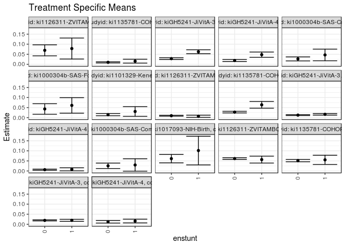

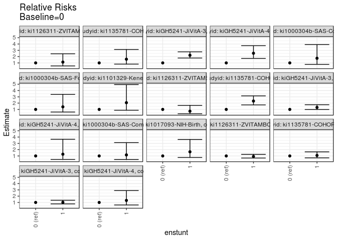

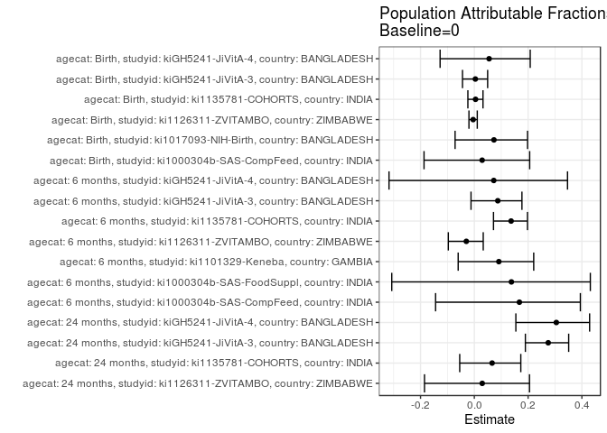

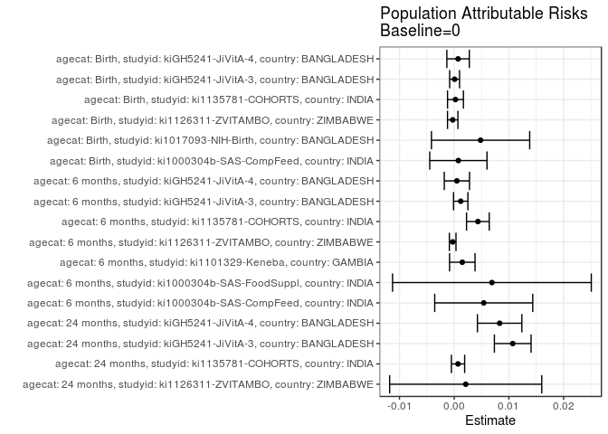

## Results Table

### Parameter: TSM

| agecat | studyid | country | intervention_level | baseline_level | estimate | ci_lower | ci_upper |
| --- | --- | --- | --- | --- | --- | --- | --- |
| Birth | ki1000304b-SAS-CompFeed | INDIA | 0 | NA | 0.0255272 | 0.0120773 | 0.0389770 |
| Birth | ki1000304b-SAS-CompFeed | INDIA | 1 | NA | 0.0297030 | -0.0011491 | 0.0605550 |
| Birth | ki1017093-NIH-Birth | BANGLADESH | 0 | NA | 0.0612648 | 0.0403513 | 0.0821784 |
| Birth | ki1017093-NIH-Birth | BANGLADESH | 1 | NA | 0.1014493 | 0.0301480 | 0.1727506 |
| Birth | ki1126311-ZVITAMBO | ZIMBABWE | 0 | NA | 0.0615850 | 0.0573237 | 0.0658463 |
| Birth | ki1126311-ZVITAMBO | ZIMBABWE | 1 | NA | 0.0565217 | 0.0392906 | 0.0737529 |
| Birth | ki1135781-COHORTS | INDIA | 0 | NA | 0.0514364 | 0.0457577 | 0.0571152 |
| Birth | ki1135781-COHORTS | INDIA | 1 | NA | 0.0552632 | 0.0322877 | 0.0782386 |
| Birth | kiGH5241-JiVitA-3 | BANGLADESH | 0 | NA | 0.0192986 | 0.0166446 | 0.0219526 |
| Birth | kiGH5241-JiVitA-3 | BANGLADESH | 1 | NA | 0.0197523 | 0.0148166 | 0.0246879 |
| Birth | kiGH5241-JiVitA-4 | BANGLADESH | 0 | NA | 0.0122262 | 0.0059043 | 0.0185481 |
| Birth | kiGH5241-JiVitA-4 | BANGLADESH | 1 | NA | 0.0161663 | 0.0068108 | 0.0255218 |
| 6 months | ki1000304b-SAS-CompFeed | INDIA | 0 | NA | 0.0268318 | 0.0168935 | 0.0367701 |
| 6 months | ki1000304b-SAS-CompFeed | INDIA | 1 | NA | 0.0465753 | 0.0176093 | 0.0755413 |
| 6 months | ki1000304b-SAS-FoodSuppl | INDIA | 0 | NA | 0.0431035 | 0.0169358 | 0.0692711 |
| 6 months | ki1000304b-SAS-FoodSuppl | INDIA | 1 | NA | 0.0608108 | 0.0222580 | 0.0993636 |
| 6 months | ki1101329-Keneba | GAMBIA | 0 | NA | 0.0147913 | 0.0093520 | 0.0202307 |
| 6 months | ki1101329-Keneba | GAMBIA | 1 | NA | 0.0306122 | 0.0064899 | 0.0547346 |
| 6 months | ki1126311-ZVITAMBO | ZIMBABWE | 0 | NA | 0.0095650 | 0.0073812 | 0.0117488 |
| 6 months | ki1126311-ZVITAMBO | ZIMBABWE | 1 | NA | 0.0068729 | 0.0013921 | 0.0123536 |
| 6 months | ki1135781-COHORTS | INDIA | 0 | NA | 0.0273450 | 0.0232298 | 0.0314603 |
| 6 months | ki1135781-COHORTS | INDIA | 1 | NA | 0.0637255 | 0.0469648 | 0.0804862 |
| 6 months | kiGH5241-JiVitA-3 | BANGLADESH | 0 | NA | 0.0125075 | 0.0102347 | 0.0147803 |
| 6 months | kiGH5241-JiVitA-3 | BANGLADESH | 1 | NA | 0.0164351 | 0.0125236 | 0.0203467 |
| 6 months | kiGH5241-JiVitA-4 | BANGLADESH | 0 | NA | 0.0063346 | 0.0034734 | 0.0091958 |
| 6 months | kiGH5241-JiVitA-4 | BANGLADESH | 1 | NA | 0.0080882 | 0.0004499 | 0.0157266 |
| 24 months | ki1126311-ZVITAMBO | ZIMBABWE | 0 | NA | 0.0694864 | 0.0420614 | 0.0969115 |
| 24 months | ki1126311-ZVITAMBO | ZIMBABWE | 1 | NA | 0.0784314 | 0.0261967 | 0.1306660 |
| 24 months | ki1135781-COHORTS | INDIA | 0 | NA | 0.0098840 | 0.0070416 | 0.0127264 |
| 24 months | ki1135781-COHORTS | INDIA | 1 | NA | 0.0156986 | 0.0060444 | 0.0253527 |
| 24 months | kiGH5241-JiVitA-3 | BANGLADESH | 0 | NA | 0.0282381 | 0.0238226 | 0.0326535 |
| 24 months | kiGH5241-JiVitA-3 | BANGLADESH | 1 | NA | 0.0624768 | 0.0527563 | 0.0721972 |
| 24 months | kiGH5241-JiVitA-4 | BANGLADESH | 0 | NA | 0.0189349 | 0.0137907 | 0.0240791 |
| 24 months | kiGH5241-JiVitA-4 | BANGLADESH | 1 | NA | 0.0479705 | 0.0349167 | 0.0610243 |

### Parameter: E(Y)

| agecat | studyid | country | intervention_level | baseline_level | estimate | ci_lower | ci_upper |
| --- | --- | --- | --- | --- | --- | --- | --- |
| Birth | ki1000304b-SAS-CompFeed | INDIA | NA | NA | 0.0262919 | 0.0122874 | 0.0402964 |
| Birth | ki1017093-NIH-Birth | BANGLADESH | NA | NA | 0.0660870 | 0.0457632 | 0.0864107 |
| Birth | ki1126311-ZVITAMBO | ZIMBABWE | NA | NA | 0.0613145 | 0.0571772 | 0.0654519 |
| Birth | ki1135781-COHORTS | INDIA | NA | NA | 0.0516712 | 0.0461576 | 0.0571849 |
| Birth | kiGH5241-JiVitA-3 | BANGLADESH | NA | NA | 0.0193738 | 0.0169653 | 0.0217823 |
| Birth | kiGH5241-JiVitA-4 | BANGLADESH | NA | NA | 0.0129382 | 0.0075150 | 0.0183614 |
| 6 months | ki1000304b-SAS-CompFeed | INDIA | NA | NA | 0.0322339 | 0.0235219 | 0.0409459 |
| 6 months | ki1000304b-SAS-FoodSuppl | INDIA | NA | NA | 0.0500000 | 0.0280580 | 0.0719420 |
| 6 months | ki1101329-Keneba | GAMBIA | NA | NA | 0.0162757 | 0.0108484 | 0.0217031 |
| 6 months | ki1126311-ZVITAMBO | ZIMBABWE | NA | NA | 0.0092887 | 0.0072498 | 0.0113275 |
| 6 months | ki1135781-COHORTS | INDIA | NA | NA | 0.0316788 | 0.0275309 | 0.0358267 |
| 6 months | kiGH5241-JiVitA-3 | BANGLADESH | NA | NA | 0.0137035 | 0.0116269 | 0.0157801 |
| 6 months | kiGH5241-JiVitA-4 | BANGLADESH | NA | NA | 0.0068281 | 0.0038634 | 0.0097927 |
| 24 months | ki1126311-ZVITAMBO | ZIMBABWE | NA | NA | 0.0715935 | 0.0472820 | 0.0959051 |
| 24 months | ki1135781-COHORTS | INDIA | NA | NA | 0.0105840 | 0.0078264 | 0.0133416 |
| 24 months | kiGH5241-JiVitA-3 | BANGLADESH | NA | NA | 0.0389399 | 0.0346167 | 0.0432631 |
| 24 months | kiGH5241-JiVitA-4 | BANGLADESH | NA | NA | 0.0272439 | 0.0220352 | 0.0324527 |

### Parameter: RR

| agecat | studyid | country | intervention_level | baseline_level | estimate | ci_lower | ci_upper |
| --- | --- | --- | --- | --- | --- | --- | --- |
| Birth | ki1000304b-SAS-CompFeed | INDIA | 0 | 0 | 1.0000000 | 1.0000000 | 1.000000 |
| Birth | ki1000304b-SAS-CompFeed | INDIA | 1 | 0 | 1.1635816 | 0.4343503 | 3.117120 |
| Birth | ki1017093-NIH-Birth | BANGLADESH | 0 | 0 | 1.0000000 | 1.0000000 | 1.000000 |
| Birth | ki1017093-NIH-Birth | BANGLADESH | 1 | 0 | 1.6559140 | 0.7580633 | 3.617179 |
| Birth | ki1126311-ZVITAMBO | ZIMBABWE | 0 | 0 | 1.0000000 | 1.0000000 | 1.000000 |
| Birth | ki1126311-ZVITAMBO | ZIMBABWE | 1 | 0 | 0.9177839 | 0.6713896 | 1.254603 |
| Birth | ki1135781-COHORTS | INDIA | 0 | 0 | 1.0000000 | 1.0000000 | 1.000000 |
| Birth | ki1135781-COHORTS | INDIA | 1 | 0 | 1.0743971 | 0.6987960 | 1.651883 |
| Birth | kiGH5241-JiVitA-3 | BANGLADESH | 0 | 0 | 1.0000000 | 1.0000000 | 1.000000 |
| Birth | kiGH5241-JiVitA-3 | BANGLADESH | 1 | 0 | 1.0235076 | 0.7755596 | 1.350725 |
| Birth | kiGH5241-JiVitA-4 | BANGLADESH | 0 | 0 | 1.0000000 | 1.0000000 | 1.000000 |
| Birth | kiGH5241-JiVitA-4 | BANGLADESH | 1 | 0 | 1.3222671 | 0.6048868 | 2.890442 |
| 6 months | ki1000304b-SAS-CompFeed | INDIA | 0 | 0 | 1.0000000 | 1.0000000 | 1.000000 |
| 6 months | ki1000304b-SAS-CompFeed | INDIA | 1 | 0 | 1.7358272 | 0.7704191 | 3.910983 |
| 6 months | ki1000304b-SAS-FoodSuppl | INDIA | 0 | 0 | 1.0000000 | 1.0000000 | 1.000000 |
| 6 months | ki1000304b-SAS-FoodSuppl | INDIA | 1 | 0 | 1.4108107 | 0.5864838 | 3.393763 |
| 6 months | ki1101329-Keneba | GAMBIA | 0 | 0 | 1.0000000 | 1.0000000 | 1.000000 |
| 6 months | ki1101329-Keneba | GAMBIA | 1 | 0 | 2.0696064 | 0.8674280 | 4.937898 |
| 6 months | ki1126311-ZVITAMBO | ZIMBABWE | 0 | 0 | 1.0000000 | 1.0000000 | 1.000000 |
| 6 months | ki1126311-ZVITAMBO | ZIMBABWE | 1 | 0 | 0.7185426 | 0.3134818 | 1.646996 |
| 6 months | ki1135781-COHORTS | INDIA | 0 | 0 | 1.0000000 | 1.0000000 | 1.000000 |
| 6 months | ki1135781-COHORTS | INDIA | 1 | 0 | 2.3304219 | 1.7212024 | 3.155274 |
| 6 months | kiGH5241-JiVitA-3 | BANGLADESH | 0 | 0 | 1.0000000 | 1.0000000 | 1.000000 |
| 6 months | kiGH5241-JiVitA-3 | BANGLADESH | 1 | 0 | 1.3140232 | 0.9896145 | 1.744777 |
| 6 months | kiGH5241-JiVitA-4 | BANGLADESH | 0 | 0 | 1.0000000 | 1.0000000 | 1.000000 |
| 6 months | kiGH5241-JiVitA-4 | BANGLADESH | 1 | 0 | 1.2768382 | 0.4468931 | 3.648111 |
| 24 months | ki1126311-ZVITAMBO | ZIMBABWE | 0 | 0 | 1.0000000 | 1.0000000 | 1.000000 |
| 24 months | ki1126311-ZVITAMBO | ZIMBABWE | 1 | 0 | 1.1287298 | 0.5204485 | 2.447948 |
| 24 months | ki1135781-COHORTS | INDIA | 0 | 0 | 1.0000000 | 1.0000000 | 1.000000 |
| 24 months | ki1135781-COHORTS | INDIA | 1 | 0 | 1.5882875 | 0.8055498 | 3.131597 |
| 24 months | kiGH5241-JiVitA-3 | BANGLADESH | 0 | 0 | 1.0000000 | 1.0000000 | 1.000000 |
| 24 months | kiGH5241-JiVitA-3 | BANGLADESH | 1 | 0 | 2.2125003 | 1.7742644 | 2.758979 |
| 24 months | kiGH5241-JiVitA-4 | BANGLADESH | 0 | 0 | 1.0000000 | 1.0000000 | 1.000000 |
| 24 months | kiGH5241-JiVitA-4 | BANGLADESH | 1 | 0 | 2.5334409 | 1.7187759 | 3.734241 |

### Parameter: PAR

| agecat | studyid | country | intervention_level | baseline_level | estimate | ci_lower | ci_upper |
| --- | --- | --- | --- | --- | --- | --- | --- |
| Birth | ki1000304b-SAS-CompFeed | INDIA | 0 | NA | 0.0007647 | -0.0044690 | 0.0059985 |
| Birth | ki1017093-NIH-Birth | BANGLADESH | 0 | NA | 0.0048221 | -0.0041582 | 0.0138025 |
| Birth | ki1126311-ZVITAMBO | ZIMBABWE | 0 | NA | -0.0002705 | -0.0012189 | 0.0006779 |
| Birth | ki1135781-COHORTS | INDIA | 0 | NA | 0.0002348 | -0.0012176 | 0.0016872 |
| Birth | kiGH5241-JiVitA-3 | BANGLADESH | 0 | NA | 0.0000752 | -0.0008291 | 0.0009795 |
| Birth | kiGH5241-JiVitA-4 | BANGLADESH | 0 | NA | 0.0007120 | -0.0013405 | 0.0027646 |
| 6 months | ki1000304b-SAS-CompFeed | INDIA | 0 | NA | 0.0054021 | -0.0035579 | 0.0143621 |
| 6 months | ki1000304b-SAS-FoodSuppl | INDIA | 0 | NA | 0.0068966 | -0.0112717 | 0.0250648 |
| 6 months | ki1101329-Keneba | GAMBIA | 0 | NA | 0.0014844 | -0.0008441 | 0.0038129 |
| 6 months | ki1126311-ZVITAMBO | ZIMBABWE | 0 | NA | -0.0002763 | -0.0008822 | 0.0003295 |
| 6 months | ki1135781-COHORTS | INDIA | 0 | NA | 0.0043338 | 0.0022590 | 0.0064086 |
| 6 months | kiGH5241-JiVitA-3 | BANGLADESH | 0 | NA | 0.0011960 | -0.0001156 | 0.0025077 |
| 6 months | kiGH5241-JiVitA-4 | BANGLADESH | 0 | NA | 0.0004935 | -0.0018113 | 0.0027983 |
| 24 months | ki1126311-ZVITAMBO | ZIMBABWE | 0 | NA | 0.0021071 | -0.0117951 | 0.0160093 |
| 24 months | ki1135781-COHORTS | INDIA | 0 | NA | 0.0007000 | -0.0005127 | 0.0019127 |
| 24 months | kiGH5241-JiVitA-3 | BANGLADESH | 0 | NA | 0.0107018 | 0.0073482 | 0.0140555 |
| 24 months | kiGH5241-JiVitA-4 | BANGLADESH | 0 | NA | 0.0083090 | 0.0042482 | 0.0123698 |

### Parameter: PAF

| agecat | studyid | country | intervention_level | baseline_level | estimate | ci_lower | ci_upper |
| --- | --- | --- | --- | --- | --- | --- | --- |
| Birth | ki1000304b-SAS-CompFeed | INDIA | 0 | NA | 0.0290865 | -0.1870240 | 0.2058517 |
| Birth | ki1017093-NIH-Birth | BANGLADESH | 0 | NA | 0.0729665 | -0.0715119 | 0.1979640 |
| Birth | ki1126311-ZVITAMBO | ZIMBABWE | 0 | NA | -0.0044112 | -0.0199959 | 0.0109354 |
| Birth | ki1135781-COHORTS | INDIA | 0 | NA | 0.0045442 | -0.0239604 | 0.0322554 |
| Birth | kiGH5241-JiVitA-3 | BANGLADESH | 0 | NA | 0.0038828 | -0.0439567 | 0.0495301 |
| Birth | kiGH5241-JiVitA-4 | BANGLADESH | 0 | NA | 0.0550343 | -0.1272582 | 0.2078477 |
| 6 months | ki1000304b-SAS-CompFeed | INDIA | 0 | NA | 0.1675907 | -0.1440123 | 0.3943201 |
| 6 months | ki1000304b-SAS-FoodSuppl | INDIA | 0 | NA | 0.1379310 | -0.3069960 | 0.4313962 |
| 6 months | ki1101329-Keneba | GAMBIA | 0 | NA | 0.0912029 | -0.0600361 | 0.2208641 |
| 6 months | ki1126311-ZVITAMBO | ZIMBABWE | 0 | NA | -0.0297498 | -0.0967402 | 0.0331487 |
| 6 months | ki1135781-COHORTS | INDIA | 0 | NA | 0.1368039 | 0.0712970 | 0.1976902 |
| 6 months | kiGH5241-JiVitA-3 | BANGLADESH | 0 | NA | 0.0872791 | -0.0123069 | 0.1770683 |
| 6 months | kiGH5241-JiVitA-4 | BANGLADESH | 0 | NA | 0.0722718 | -0.3172077 | 0.3465878 |
| 24 months | ki1126311-ZVITAMBO | ZIMBABWE | 0 | NA | 0.0294318 | -0.1852710 | 0.2052429 |
| 24 months | ki1135781-COHORTS | INDIA | 0 | NA | 0.0661413 | -0.0543193 | 0.1728387 |
| 24 months | kiGH5241-JiVitA-3 | BANGLADESH | 0 | NA | 0.2748293 | 0.1898605 | 0.3508864 |
| 24 months | kiGH5241-JiVitA-4 | BANGLADESH | 0 | NA | 0.3049860 | 0.1544540 | 0.4287189 |